# Лабораторная работа 3

Операционные системы

Закиров Н.Д., НКАбд-03-23

Российский университет дружбы народов, Москва, Россия

27 февраля 2024

# Информация

## Докладчик

- Закиров Нурислам Дамирович
- Студент 1 курса
- Группа: НКАбд-03-23
- Российский университет дружбы народов

# Лабораторная работа

## Цель работы

Цель данной лабораторной работы - научиться оформлять отчёты с помощью легковесного языка разметки Markdown.

# Задание

- Сделайте отчёт по предыдущей лабораторной работе в формате Markdown.
- В качестве отчёта предоставляются отчёты в 3 форматах: pdf, docx и md.

## Выполнение лабораторной работы

Переходим в каталог по отчёту нашей лабораторной работы при помощи cd (рис. 1).

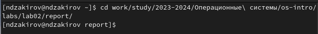

Перемещение по катологу

## Выполнение лабораторной работы

После того, как заблаговременно создали файл в формате MarkDown для отчёта по лабораторной работе, проверяем его наличие при помощи ls (рис. 2).

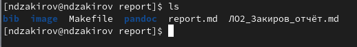

Проверка наличия

## Выполнение лабораторной работы

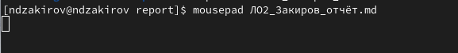

Запуск файла при помощи редактора

## Выполнение лабораторной работы

После чего мы оформляем сам отчёт(рис. 4).

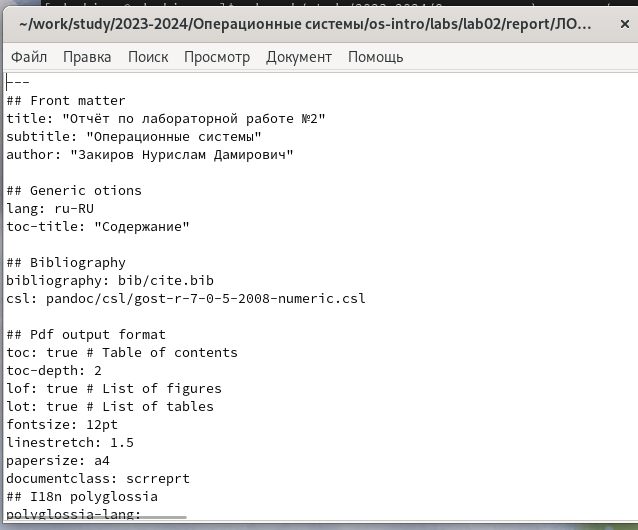

Создание отчета в редакторе

## Выполнение лабораторной работы

Следующим этапом сохраняем наши изменения и при помощи make компилируем данный отчёт в форматы pdf и docx(рис. 5).

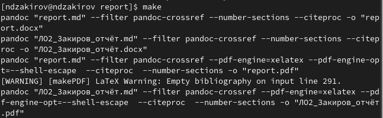

Компелирование отчёта

## Выполнение лабораторной работы

Проверяем правильность компилируемости при помощи ls(рис. 6).

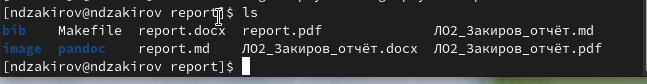

Проверка наличия

## Выполнение лабораторной работы

Так же, запускаем отчёт в формате pdf, чтобы убедиться, что программа сработала без ошибок(рис. 7).

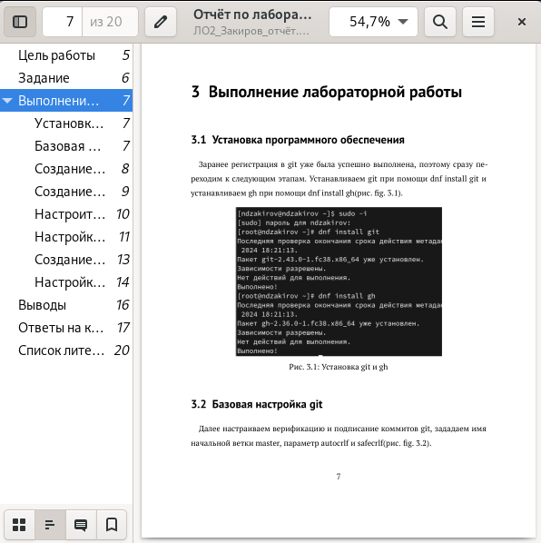

Окно отчёта в формате pdf

## Выводы

В ходе данной лаболаторной работы я научился оформлять отчёты с помощью легковесного языка разметки Markdown.